# Assignment 7: Visualization - Some aspects of ggplot2

- Use `geom_point` to compare the vaccines used by date in Argentina in 2022.

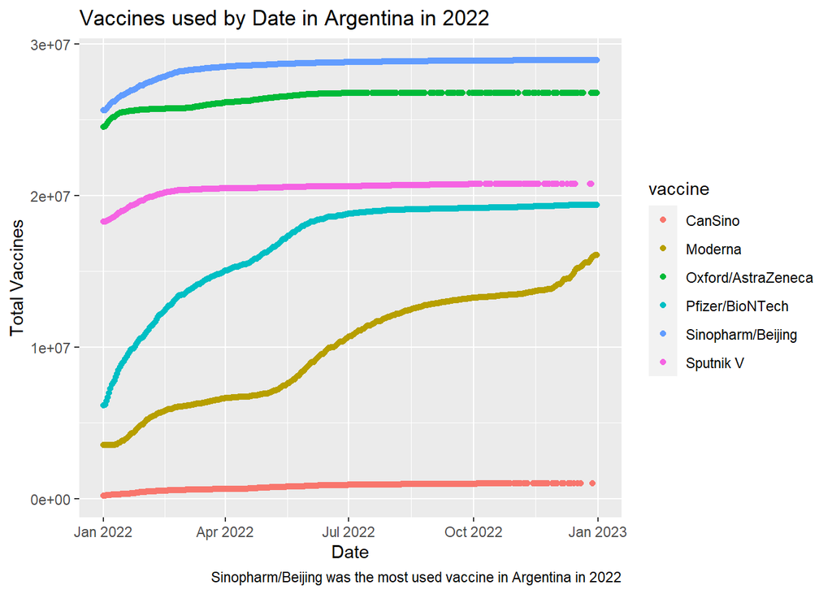

```r
df2 %>%
  filter(location=='Argentina', date >= '2022-01-01', date <= '2022-12-31') %>%
  ggplot()+
  geom_point(mapping = aes(x = date, y = total_vaccinations, color = vaccine)) +
  labs(x='Date',
       y = 'Total Vaccines',
       title = 'Vaccines used by Date in Argentina in 2022',
       caption = 'Sinopharm/Beijing was the most used vaccine in Argentina in 2022')
```

This plot shows the vaccines used in Argentina in 2022. I like this plot because you can clearly see where each vaccine type lies on the plot compared to columns.

- Change `geom_point` to `geom_line` in the above codes to have the corresponding line plots.

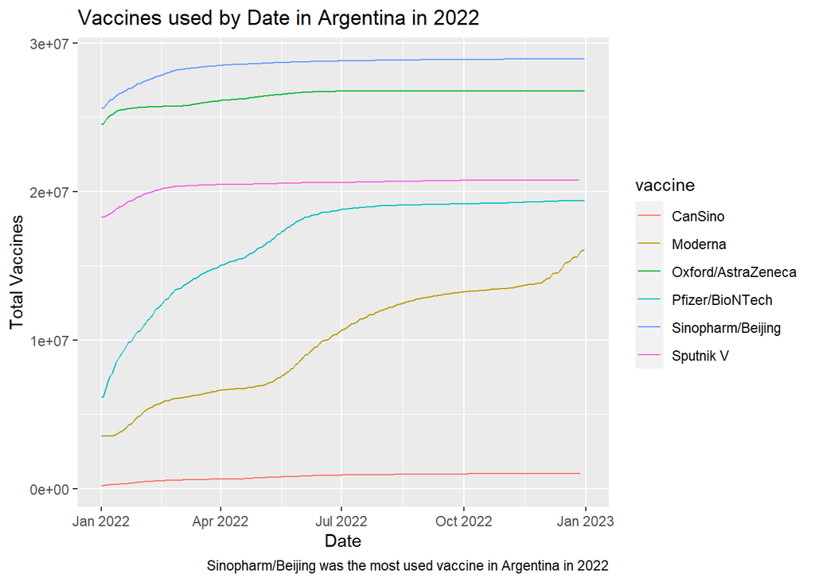

```r
df2 %>%
  filter(location=='Argentina', date >= '2022-01-01', date <= '2022-12-31') %>%
  ggplot()+
  geom_line(mapping = aes(x = date, y = total_vaccinations, color = vaccine)) +
  labs(x='Date',
       y = 'Total Vaccines',
       title = 'Vaccines used by Date in Argentina in 2022',
       caption = 'Sinopharm/Beijing was the most used vaccine in Argentina in 2022')
```

This line graph shows the vaccines used in Argentina in 2022. This is very similar to the plot graph above because the data isn’t scattered and it is more gradual, so the plotting was smooth just like the lines are.

11. (Using the same dataset as in 10.) Sometime we need to do some calculations on the data before plotting. For example, the below codes is to compare the total vaccines (including all types of vaccines) by date between the US and the EU

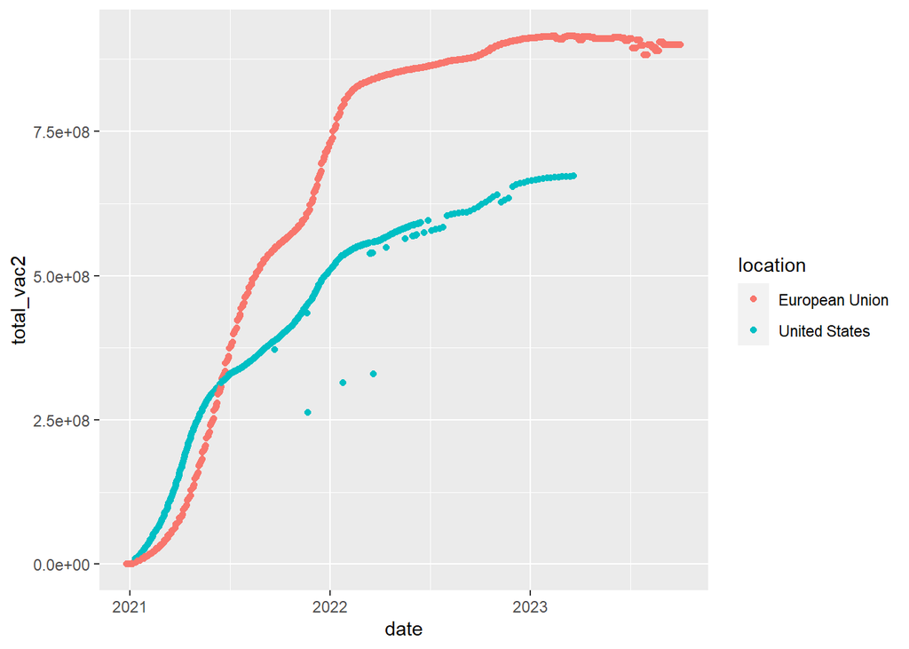

```r
# the total vaccines (including all types of vaccines) by date
d1 <- df2 %>%
  filter(location %in% c('United States', 'European Union')) %>%
  group_by(date, location) %>%
  summarise(total_vac2=sum(total_vaccinations, na.rm=TRUE))

# Plot
d1 %>%
  ggplot()+
  geom_point(mapping=aes(x=date,
                         y=total_vac2,
                         color=location))
```

Notice that the above codes could be piped in one

```r
df2 %>%
  filter(location %in% c('United States', 'European Union')) %>%
  group_by(date, location) %>%
  summarise(total_vac2=sum(total_vaccinations, na.rm=TRUE)) %>%
  ggplot()+
  geom_point(mapping=aes(x=date,
                         y=total_vac2,
                         color=location))
```

[output not shown]

Do the follows.

- Use `geom_point` compare the total vaccines (including all types of vaccines) by date between countries/regions in Asia

```r
table(df2$location)
```

```
##
##      Argentina        Austria        Belgium       Bulgaria         Canada
##           4725            617            500            430            260
##          Chile        Croatia         Cyprus        Czechia        Denmark
##           1504            527            432           3447            459
##        Ecuador        Estonia European Union        Finland         France
##           1161            495          10989            303           3537
##        Germany      Hong Kong        Hungary        Iceland        Ireland
##           3537           1751            585            151            557
##          Italy          Japan         Latvia  Liechtenstein      Lithuania
##           3017           2188           2006            210            420
##     Luxembourg          Malta          Nepal    Netherlands         Norway
##            426            424            486            497            477
##           Peru         Poland       Portugal        Romania       Slovakia
##           3025            594            883           1715            478
##       Slovenia   South Africa    South Korea          Spain         Sweden
##            444            542           3199            395            323
##    Switzerland        Ukraine  United States        Uruguay
##           2492           1491           1530           1632
```

Hong Kong, Japan, Nepal, South Korea are all in Asia

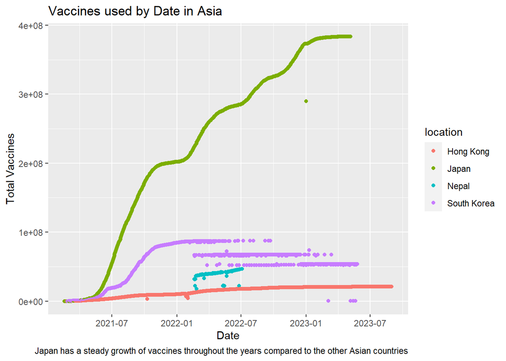

```r
df2 %>%
  filter(location %in% c('Hong Kong', 'Japan', 'Nepal', 'South Korea')) %>%
  group_by(date, location) %>%
  summarise(total_vac2=sum(total_vaccinations, na.rm=TRUE)) %>%
  ggplot()+
  geom_point(mapping=aes(x=date,
                         y=total_vac2,
                         color=location)) +
  labs(x='Date',
       y = 'Total Vaccines',
       title = 'Vaccines used by Date in Asia',
       caption = 'Japan has a steady growth of vaccines throughout the years compared to the other Asian countries')
```

- Use `geom_point` compare the total vaccines (including all types of vaccines) by date between countries/regions in South America in 2021

```r
table(df2$location)
```

```
##
##      Argentina        Austria        Belgium       Bulgaria         Canada
##           4725            617            500            430            260
##          Chile        Croatia         Cyprus        Czechia        Denmark
##           1504            527            432           3447            459
##        Ecuador        Estonia European Union        Finland         France
##           1161            495          10989            303           3537
##        Germany      Hong Kong        Hungary        Iceland        Ireland
##           3537           1751            585            151            557
##          Italy          Japan         Latvia  Liechtenstein      Lithuania
##           3017           2188           2006            210            420
##     Luxembourg          Malta          Nepal    Netherlands         Norway
##            426            424            486            497            477
##           Peru         Poland       Portugal        Romania       Slovakia
##           3025            594            883           1715            478
##       Slovenia   South Africa    South Korea          Spain         Sweden
##            444            542           3199            395            323
##    Switzerland        Ukraine  United States        Uruguay
##           2492           1491           1530           1632
```

Argentina, Chile, Ecuador, Peru, Uruguay are all in South America

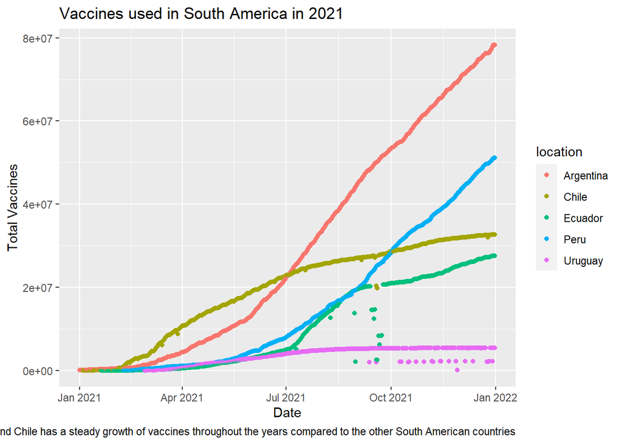

```r
df2 %>%
  filter(location %in% c('Argentina', 'Chile', 'Ecuador', 'Peru', 'Uruguay'),date >= '2021-01-01', date <= '2021-12-31' ) %>%
  group_by(date, location) %>%
  summarise(total_vac2=sum(total_vaccinations, na.rm=TRUE)) %>%
  ggplot()+
  geom_point(mapping=aes(x=date,
                         y=total_vac2,
                         color=location)) +
  labs(x='Date',
       y = 'Total Vaccines',
       title = 'Vaccines used in South America in 2021',
       caption = 'Argentina, Peru, and Chile has a steady growth of vaccines throughout the years compared to the other South American countries')
```

This graph shows the total vaccines used/taken in South America in 2021 grouped by date and location. You can clearly see that countries such as Argentina, Peru, and Chile have a steady growth of vaccines.